# SSA 200 Course Evaluation

Anna Tucker

October 29, 2018

### Pre- and post-class assessment

We asked four multiple choice questions before and after the course to assess both baseline understanding and our effectiveness at communicating some key ideas.

#### Questions

*The correct answers are in bold*

**1. What is a model?**  
a. Someone who walks in fashion shows and is photographed a lot.  
b. A mathematical equation.  
**c. A simplified representation of reality.**  
d. A computer program used to predict future events.

**2. What information does a regression coefficient tell you?**  
**a. It quantifies the relationship between a predictor variable and a response variable.**  
b. It describes the correlation between two predictor variables in the model.  
c. It tells you the probability that a covariate is an important predictor of the response variable.  
d. It tells you how close the observed value is to the mean.

**3. What types of uncertainty can we resolve using statistical models?**  
a. Demographic stochasticity and observational uncertainty  
**b. Observational uncertainty and ecological uncertainty**  
c. Partial controllability and environmental stochasticity  
d. Environmental stochasticity and demographic stochasticity

**4. Which of the following statements is a correct interpretation of the population projection below?**  
*The solid line is the median and the dashed lines are the 95% confidence intervals*  
a. This population has high resiliency.  
b. This population will most likely be extinct in 30 years.  
**c. This population will most likely remain stable for the next 30 years.**  
d. It is more likely than not that there will be at least 1000 individuals in the population in 30 years.

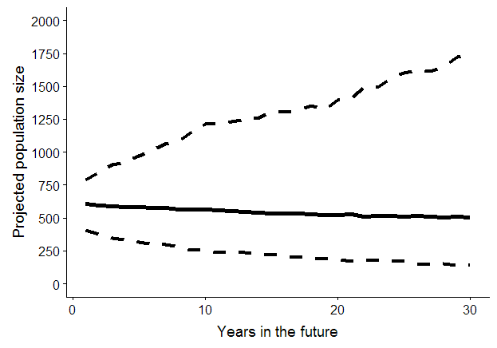

#### Reponses

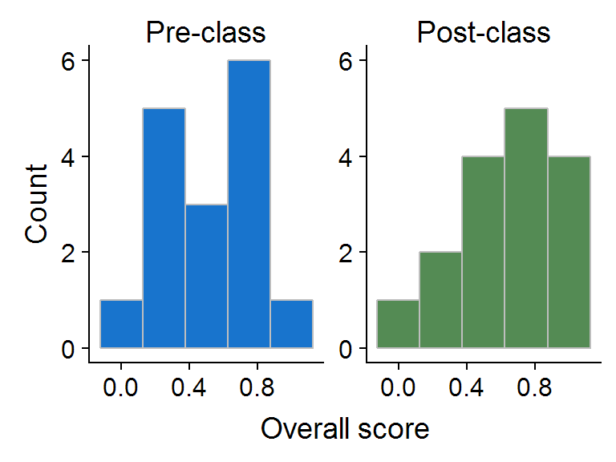

| type | Average score |
| --- | --- |
| Pre-class | 0.516 |
| Post-class | 0.641 |

Overall the assessment scores improved after the class, with the average increasing from 0.516 before the course to 0.641 after. The overall distribution of scores shifted higher.

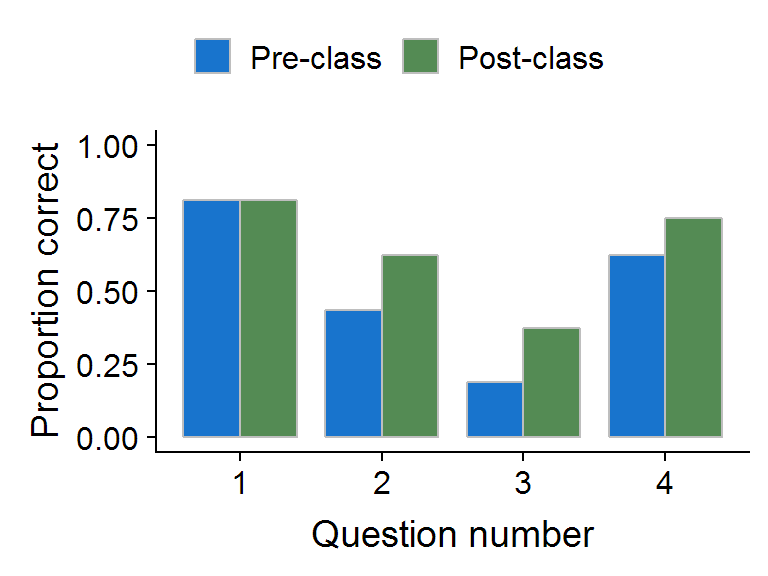

The proportion of correct answer improved for all questions except for question 1, which most students answered correctly before the class as well.

#### Course evaluations

We asked students to complete an anonymous course evaluation via Google Forms.

```
## Sheet successfully identified: "SSA 200 Course Evaluation (Responses)"
```

```
## Accessing worksheet titled 'Form Responses 1'.
```

Most of the questions had the students choose a response that ranged from 1 (low) to 5 (high).

| question |
| --- |
| Overall, how was the material in this course organized and presented? |
| How well did the course meeting the objective: Become familiar with common terminology and approaches used in population modeling including constraints, weaknesses, and underlying assumptions. |
| How well did the course meet the objective: Identify an appropriate analytical approach for assessing the status of a species given the available data. |
| How well did the course meet the objective: Communicate/understand relevant analytics and interpret population modeling results pertinent to an SSA. |
| How well did the course meet the objective: Communicate population modeling results to decision makers as part of SSA results. |
| Overall, how useful will the information from this course be in performing your job? |

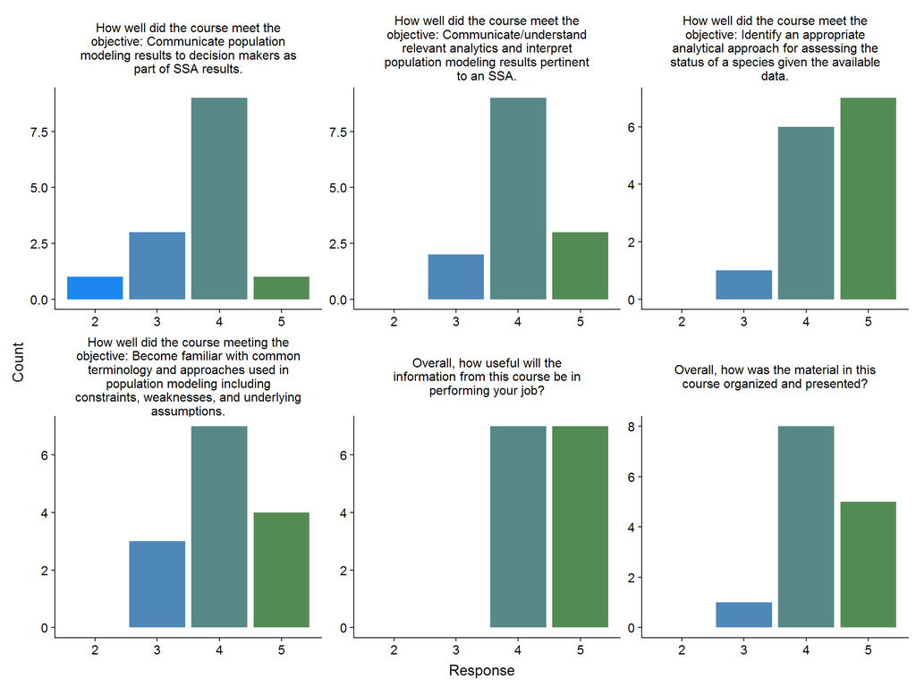

One question asked students to evaluate the level of detail provided, with 1 = too little, 5 = too much, and 3 = just right.

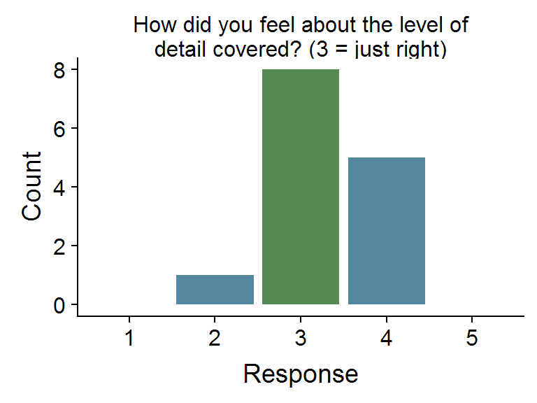

The final three questions were open-ended.

What can we do to improve the effectiveness of this course?

NA

I haven’t taken a math or stats class in forever so more pre-class material to read on the types of models might have been helpful for me. It was hard on the last exercise to remember all the models and digest that in 2 days to do the exercise.

I think three days might be better. Maybe some more background reading prior to the class about the basics of stats/modeling would be helpful. I would like to see more real life examples of how data were used in SSAs. Possibly more exercises; maybe shorter, more narrowly focused exercises - those help me the most. So, maybe pausing at various points in the presentations for 5-10 minutes with “quiz” type questions that force us to think about what was just presented. And if given the option I will work independently, but I get a lot out of the group work, so I think having an intentional mix of small group and individual work would be great. I want more cheat-sheets like the flow chart, so any other resources you could develop that would help walk us through making these kinds of decisions would be really helpful - particularly in understanding how to use the covariates in the different modeling types, and what demographic metrics the different modeling types would produce or need for inputs.

Another day where you go into more depth about why certain models are better and how the outputs can directly address the 3Rs would help inform how to present to recommenders

I think overall the course was well organized, helpful, and informative for doing this type of analysis. The last exercise was very informative because it made the attendees really think through the available data they had and pick the most appropriate models to run. Also, some of the data you get during SSAs isnt useful and understanding that you may not be able to use all the information is just as important.

Id like to see the very first model co-variate picking exercise shortened. I think that saved time could be applied to the later exercises and allow students more time to ask questions, and really think through and digest the material. I think even adding a section where folks (likely FWS) can explain how some of these tools were actually used in a SSA/RTM and walk through a case study would be beneficial. This would allow students to actually see how these tools are used and applied in their job(s).

Keep future analysis portion a little less technical…maybe more general…I felt a bit overwhelmed during the latter parts of day 2

I’m not sure it’s possible, but I think the main thing that would improve the course effectiveness is to tailor it more toward people’s personal backgrounds. This is a very specific class but the students had such a wide range of prior education and experience with SSA that it was constrained to a pretty high-level overview. I thought it was effective as a high-level overview but that it would be irresponsible to say that the objectives listed above were fully met; I don’t think those objectives can be met with a 2-day class of this nature. I think the class is totally on the right track but you can’t have everything.

1. Repeat or summarize the important concepts after each topic/lecture; it’s a lot to take in and this would help reinforce the main take-home messages. (2) For the non-statisticians in the audience, use terminology consistently, for example some similar terms seemed to be used interchangeably like “environmental stochasticity” and “environmental variability” or “beta” and “covariate”. Perhaps a short glossary (cheat sheet) would be an easy fix for those of us who get lost. (3) a lot of students are very rusty on their graduate statistics classes so a prerequisite of some sort to prepare them for this class could be considered.

This may seem trivial, but typos in the materials made some things confusing (there is even a typo in this evaluation). The lecture on state transitions especially (the order of states was different between Conor and Anna). Please re-read all of the materials and make sure there are no inconsistencies. I also think a 3-day course with slower lectures and smaller activities in between lectures would help understanding of the material.

The exercises were okay, but you might try using a “case study” approach with an actual, recent SSA that has used different modeling tools and go through that.

You did a masterful job of creating a succinct course! Well done. However, I think the students would be better served with more time to absorb the info. I recommend 3 days for roughly the same info, but with more repetition and done so in different ways to accommodate different learning styles. More short exercises that “circled-back” to reinforce the main topic of that ‘module’ would’ve helped reinforce the info (and also helped break up the lectures). So, in the above questions, the level of detail was “just right,” but the time to absorb it wasn’t. More time would (probably) have bumped up the scores I gave in the subsequent “meet the objectives” questions.

I know its a very short course, but perhaps more, ‘this-world real SSA used this type of analysis’ and here’s why.

Find a way to better tie the coursework into a common thread. Portions of it never seem to really “click” because they are lectured on then a few questions are asked and that’s about it. The most revelatory thing part for me was when a question was asked about the St. Croix rat analysis and “where those numbers in the table came from?” and then try Conor very nicely tied those numbers being reported to previous analysis just like the ones we reviewed.

Make it a week, 2 days was very overwhelming. By the end I could understand how the flow chart of models worked, but couldn’t remember what each one actually does/tells us. Maybe a sheet that categorizes each model type would be helpful? We kept discussing how we will likely be reading about modeling in papers during the SSA process, but we never actually read any real papers or had real paper examples (that weren’t super simplified). An activity where we have to read part of a paper and dive into why they did it how they did would be helpful. An example SSA as to where modeling would fit into it structurally would be helpful as well, along with practicing how to write it into the SSA.

[output not shown]

[output not shown]